# S1.4d: il nucleo ritagliato nel territorio e riportato all’area giusta entra nel pacchetto e riproduce i contatti contati a mano?

geo_spatialtrans, report di step (protocollo v2)

Published

October 20, 2026

# In breve

## In breve: il nucleo «ritagliato nella sua cellula e riportato all’area giusta» è entrato nel simulatore e riproduce i contatti fra nuclei che hai contato a mano?

**A cosa serviva.** Nei tessuti densi i nuclei veri si toccano e si deformano. Nel confronto precedente avevamo scelto di disegnare ogni nucleo ritagliandolo dentro la sua cellula e poi ingrandendolo finché ha l’area voluta. Qui quel metodo è diventato il comportamento normale del simulatore. Abbiamo controllato tre cose: che sia identico al prototipo, che i nuclei non escano mai dalla loro cellula né si sovrappongano, e che la frazione di nuclei a contatto stia nel margine del tuo conteggio manuale.

**Cosa abbiamo trovato.**

1. **In cinque tessuti su sei la frazione di nuclei a contatto sta nel margine del tuo conteggio; nel linfonodo è sul bordo.**
   - Intestino di topo 0.50 (tu 0.50), tumore del colon 0.48 (tu 0.37), stroma del tumore 0.18 (tu 0.18), cervello di topo 0.08 (tu 0.08), cuore 0.05 (tu 0.02).
   - Nel linfonodo 0.74, contro il tuo 0.55, con un margine che arriva a 0.75.
   - Il modello vecchio, che rimpiccioliva il nucleo invece di ritagliarlo, non produce quasi nessun contatto: zero in intestino, tumore e stroma, 2 su 100 nel linfonodo. Il confronto con il tuo conteggio distingue quindi davvero i due modelli.
2. **L’eccesso di contatti nel linfonodo dipende da quali centri dei nuclei usiamo.**
   - Con i centri trovati da Space Ranger i contatti sono 0.74. Con quelli di StarDist, che vede meno nuclei, scendono a 0.41, dentro il tuo margine.
   - Il tuo 0.55 sta in mezzo. Quale insieme di centri usare nel linfonodo si deciderà quando sceglieremo una sola maschera per linfonodo e cuore.
3. **Nel tumore del colon il 6 % delle cellule simulate resta quasi senza citoplasma (nucleo ≥ 95 % della cellula), contro al più il 3 % nei tessuti reali.**
   - La causa non è il ritaglio. Il modello che sceglie la taglia del nucleo chiede già nuclei così grandi nel 6 % delle cellule, contro il 2 % dei nuclei veri.
   - Nel tumore del colon non c’è un limite massimo all’area del nucleo rispetto alla sua cellula, perché nei dati veri alcuni nuclei superano persino il territorio. Così quella coda passa intera nel simulato.
4. **Il programma nuovo è identico al prototipo, non mette mai un nucleo fuori dalla sua cellula né sopra un vicino, ed è circa tre volte più veloce.**
   - Su 6.8 milioni di nuclei, nessuno esce dalla sua cellula e nessuna coppia si sovrappone.
   - Su 2.4 milioni di nuclei confrontati con il prototipo, le aree coincidono a meno di un milionesimo e i nuclei fermati dal limite sono gli stessi.
   - Il modello vecchio resta disponibile ed è identico a prima, così i risultati passati si riproducono.
   - Una sezione di 450 000 cellule richiede 3 minuti e 45 secondi, contro i 10 minuti e 23 secondi del prototipo.
5. **Un solo controllo di precisione è fallito, per una soglia scelta male da me e non per un errore del programma.**
   - Avevo chiesto che ogni area fosse esatta a un milionesimo. Un nucleo artificiale di 0.18 µm², nato in un tessuto di punti messi a caso, sbaglia di 1.5 milionesimi.
   - Per nuclei così piccoli il milionesimo è sotto la finezza della griglia di calcolo. Nei tessuti reali l’errore più grande è 0.7 milionesimi.

**Cosa devi decidere.**

1. **Accettiamo che il controllo di precisione sia fallito per una soglia sbagliata, e non consideriamo il programma difettoso? Consiglio di sì.**
   - L’unico nucleo oltre la soglia è più di venti volte più piccolo del nucleo più piccolo misurato nei tessuti veri (4 µm²), e il suo errore è sette volte sotto quello che la griglia permette. I due revisori indipendenti sono arrivati alla stessa conclusione.
   - Alternativa: rendere più fine la griglia di calcolo. Vorrebbe dire riaprire la scelta fatta quando abbiamo confrontato i metodi di intersezione, senza cambiare nulla nei tessuti reali.
2. **Lasciamo il tumore del colon senza limite sull’area del nucleo, e correggiamo la coda del modello di taglia quando introdurremo i diversi tipi di cellula? Consiglio di sì.**
   - Nel tumore convivono cellule tumorali, stroma e cellule immunitarie. Un solo modello di taglia per tutte allarga la coda, e la cura giusta è un modello per tipo.
   - Alternativa: limitare il nucleo al 95 % della cellula. Le cellule senza citoplasma sparirebbero, ma i nuclei troncati salirebbero dal 4.7 % al 5.5 %, sopra la soglia del 5 %, e resterebbero cellule con appena il 5 % di citoplasma.
   - Alternativa: limitarlo al 90 %. I troncati salirebbero al 6.5 %.

**Comunque**, quando sceglieremo una sola maschera per linfonodo e cuore decideremo anche da quali centri partire nel linfonodo. Quando introdurremo i diversi tipi di cellula rivedremo la coda del modello di taglia. In quella occasione guarderemo anche i pochissimi nuclei che finiscono divisi in più pezzi: 8 su 2.4 milioni, di cui uno con due quinti dell’area in frammenti staccati della sua cellula.

Appena decidi questi 2 punti, lo step è chiuso.

# Decisioni e verifiche di Luca

- Ok sulle previsioni e sui loro intervalli: «Approvo così» (trascritto dalla chat, 2026-10-20).
- Decisione 1 del riassunto, alla domanda «Accettiamo che il controllo di precisione sulle aree sia fallito per una soglia sbagliata (un nucleo artificiale di 0.18 µm² in un tessuto di punti a caso, errore sotto la finezza della griglia) e non per un difetto del programma?»: «Sì, è un errore di soglia» (trascritto dalla chat, 2026-10-20) → Il controllo di precisione sulle aree fallito in S1.4d è un errore della soglia, non del programma (DEC-004).
- Decisione 2 del riassunto, alla domanda «Nel tumore del colon il 6 % delle cellule simulate resta quasi senza citoplasma (reale al più 3 %), per colpa della coda del modello di taglia. Cosa facciamo con il limite all’area del nucleo in quel tessuto?»: «Nessun limite; si corregge il modello di taglia con i tipi cellulari» (trascritto dalla chat, 2026-10-20) → Nel tumore del colon nessun limite all’area del nucleo; la coda del modello di taglia si corregge con i tipi cellulari (DEC-005).
- Luca ha letto il riassunto e deciso i due punti senza sollevare dubbi nuovi: **step chiuso**.

# Dubbi rinviati

| cosa | perché | cosa serve per chiuderlo | step destinatario | voce di BACKLOG |
| --- | --- | --- | --- | --- |
| Linfonodo: frazione di contatti 0.74 con i centri Space Ranger, 0.41 con StarDist, manuale 0.55 (previsione P-1 indeterminata, P-4 confermata) | la scelta dei centri è la scelta della maschera unica di linfonodo e cuore | scegliere la maschera (Space Ranger, StarDist o consenso) e rifare la frazione di contatti sulle finestre | R3b | BL-130 (aggiornata), BL-121 |
| Coda alta del modello di taglia: bersagli ≥ 0.95 del territorio 5.8 % contro 2.0 % reali nel tumore del colon; la stessa coda diventa troncamento negli altri tessuti | il modello lognormale a un tipo mescola tipi cellulari diversi (σ 0.55 nel tumore) | modello di taglia per tipo cellulare; ricontrollare cellule senza citoplasma e troncamento | S1.5 (composizione per tipi) | BL-138 |
| Nuclei in più parti: 8 su 2 411 650 nei tessuti reali, 32 nei nulli; uno con il 41 % dell’area in frammenti staccati del territorio | il ritaglio usa tutto il territorio, anche i frammenti orfani di S1.3 | decidere se limitare il nucleo alla parte del territorio che contiene il generatore | S1.5 | BL-139 |
| Arresto del solutore legato alla griglia: euristica, ferma il 5.9 % delle celle sopra la tolleranza obiettivo 1e-7 (tutte entro 7.4e-7) | nessuna conseguenza sui numeri; efficienza migliorabile (F-06) | solo se servirà più precisione o velocità: arresto per ristagno dell’area | da assegnare | BL-140 |

# Cancelli

Pre-registrazione: commit `5118bce` (cancelli), ok di Luca sulle previsioni il 2026-10-20 (commit `eae40f6`, «Approvo così»). Note di sviluppo D-1…D-7 scritte prima del banco (commit `3dda369`).

| cancello | controllo | valore | soglia | superato |
| --- | --- | --- | --- | --- |
| G-3 | C3 (geos), nuclei fuori dal territorio | 0 | 0 | TRUE |
| G-3 | C3 (sf via WKB), nuclei fuori dal territorio | 0 | 0 | TRUE |
| G-3 | coppie sovrapposte > 1e-9 µm² | 0 | 0 | TRUE |
| G-3 | area relativa max \|A - A*\| / A* | 1.46e-06 | <= 1e-6 | FALSE |
| G-3 | geometrie invalide / vuote | 0 0 | 0 / 0 | TRUE |
| G-3 | nulli rigenerati = S1.4 (n, seme) | 60 | 60/60 | TRUE |
| G-3 | riproducibilita’ bit per bit (md5) | 6 | 6/6 | TRUE |
| G-4a | forma pre-registrata: celle con differenza simmetrica / A* > 1e-6 | 0 | 0 | TRUE |
| G-4a | stesse celle al tetto del prototipo (unita’ x seme) | 300 | 300/300 | TRUE |
| G-4a* | spiegazione: \|dA\| / A* max (accordo d’area) | 7.45e-07 | <= 1e-6 | TRUE |
| G-4a* | spiegazione: celle oltre il limite del rumore di griglia | 0 | 0 | TRUE |
| G-4a+ | cella per cella: celle troncate diverse dal prototipo (300 unita’ x seme) | 0 | 0 | TRUE |
| G-4a+ | codice corretto dopo la revisione: md5 del seme 1 = banco | 30 | 30/30 | TRUE |
| G-4b | modo scale = pacchetto db4afea (cell_df e WKB) | 330 | 330/330 | TRUE |
| G-4b | modo scale = righe V-c di S1.4b (C-0) | 330 | 330/330 | TRUE |
| controllo | codice delle finestre = R2c (prototipo K-2: n e contatti identici) | 240 | 240/240 | TRUE |
| CP-1 | vecchio modello non smentito nei tessuti densi (deve essere < 2) | 0 | < 2 | TRUE |

- **G-1** (batteria di test) e **G-2** (mutanti) superati: 31/31 asserzioni nuove, 63/63 di S1.4 in modo «scale» con esiti riscritti identici a quelli committati, 8/8 dello strumento OKF; 7 mutanti su 7 rilevati, M6 solo dopo l’aggiunta del test diretto dell’helper di conversione (nota D-3: il mutante è equivalente sul percorso della funzione).
- **G-3 fallito come scritto in un solo nucleo** su 6 823 226 (vedi sotto): l’errore d’area relativo massimo è 1.46e-6 contro la soglia 1e-6. Tutte le altre invarianti sono a zero.
- **G-4** superato nella forma pre-registrata: nessuna cella con differenza simmetrica / area bersaglio > 1e-6 rispetto al prototipo (il timore della nota D-2 non si è avverato sui tessuti reali); stesse celle al tetto in 300/300 unità; modo «scale» identico al pacchetto di `db4afea` e alle righe di S1.4b in 330/330.
- **G-5**: vedi «Revisione avversariale».

## Il nucleo che supera la soglia di G-3

| set | units | cells | c3_geos | c3_sf | overlap_pairs | overlap_max | area_rel_max | invalid | empty | multipart | clipped | capped | max_iter |
| --- | --- | --- | --- | --- | --- | --- | --- | --- | --- | --- | --- | --- | --- |
| primary_tissue | 300 | 2411650 | 0 | 0 | 0 | 0 | 7.0e-07 | 0 | 0 | 8 | 1148871 | 69296 | 23 |
| primary_fold | 300 | 2411650 | 0 | 0 | 0 | 0 | 7.0e-07 | 0 | 0 | 8 | 1148738 | 69770 | 23 |
| stardist | 100 | 1068060 | 0 | 0 | 0 | 0 | 5.0e-07 | 0 | 0 | 0 | 311350 | 4195 | 25 |
| null | 60 | 482330 | 0 | 0 | 0 | 0 | 1.5e-06 | 0 | 0 | 32 | 292792 | 21351 | 25 |
| section_S | 1 | 449536 | 0 | 0 | 0 | 0 | 6.0e-07 | 0 | 0 | 0 | 313715 | 1566 | 22 |

Il solo nucleo sopra 1e-6 è in un tassellamento nullo CSR (punti a caso) del linfonodo, ROI p2, seme 20280109, cella 13822: territorio 0.216 µm², nucleo 0.176 µm² (al tetto φ = 0.816), perimetro 2.64 µm, 11 iterazioni. L’errore assoluto è 2.6e-7 µm²; il limite del rumore della griglia di 1e-6 µm per quel perimetro (√2/2 · griglia · perimetro / area) vale 1.06e-5 in relativo, sette volte più dell’errore osservato. È la stessa causa della nota D-2: la tolleranza relativa di 1e-6 non è raggiungibile per nuclei sotto il µm², che nei tessuti reali non esistono (il nucleo reale più piccolo misura 4.05 µm²; errore massimo per unità 7.4e-7 nei tassellamenti primari, 4.7e-7 con StarDist, 5.7e-7 sulla sezione S). **Errore di pre-registrazione della soglia, non del software; decisione di Luca nel riassunto.**

# Previsioni

| previsione | tessuto | stima ± 2 SE | intervallo di rilevanza | esito |
| --- | --- | --- | --- | --- |
| P-1 | intestino | 0.501 ± 0.0184 | 0.366–0.650 | confermata |
| P-1 | tumore del colon | 0.482 ± 0.0133 | 0.217–0.567 | confermata |
| P-1 | stroma | 0.182 ± 0.0140 | 0.0833–0.283 | confermata |
| P-1 | linfonodo | 0.744 ± 0.0146 | 0.350–0.750 | indeterminata |
| P-1 | cervello | 0.0834 ± 0.0216 | 0–0.217 | confermata |
| P-1 | cuore | 0.0491 ± 0.0110 | 0–0.0702 | confermata |
| P-4 | linfonodo | 0.412 ± 0.0248 | 0.350–0.750 | confermata |
| P-2 | intestino | 0.0270 ± 0.00298 | 0–0.0500 | confermata |
| P-2 | tumore del colon | 0.0472 ± 0.00741 | 0–0.0500 | indeterminata |
| P-2 | stroma | 0.0330 ± 0.0248 | 0–0.0500 | indeterminata |
| P-2 | linfonodo | 0.0229 ± 0.00713 | 0–0.0500 | confermata |
| P-2 | cervello | 0.0379 ± 0.0338 | 0–0.0500 | indeterminata |
| P-2 | cuore | 0.0110 ± 0.00560 | 0–0.0500 | confermata |
| P-3 | intestino | 0 ± 0 | 0–0.00202 | confermata |
| P-3 | tumore del colon | 0.0582 ± 0.00819 | 0–0.0287 | smentita |
| P-3 | stroma | 0 ± 0 | 0–0.0208 | confermata |
| P-3 | linfonodo | 0 ± 0 | 0–0.00322 | confermata |
| P-3 | cervello | 0 ± 0 | 0–0 | confermata |
| P-3 | cuore | 0 ± 0 | 0–0 | confermata |
| P-5 (tempo, s) | sezione S | 225. ± 3.32 | 0–300. | confermata |
| P-5 (memoria, GiB; GB decimali = GiB x 1.0737) | sezione S | 6.36 ± 0 | 0–8.00 | confermata |

Atteso e fonte degli intervalli: file dello step (`docs/steps/S1.4d.md`, tabella delle previsioni). Unità: semi (P-1, P-4), ROI (P-2, P-3), ripetizioni (P-5); estremi tagliati a [0, 1] per le frazioni (nota D-5).

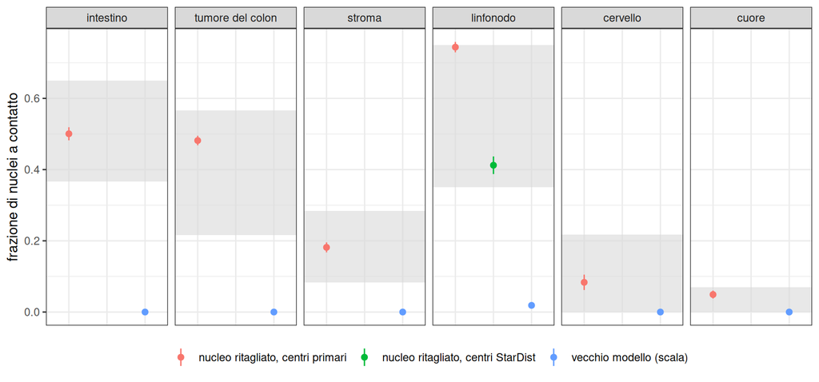

Figure 1

## Cellule quasi senza citoplasma nel tumore del colon (P-3 smentita): analisi post hoc

| tessuto | σ del modello | bersagli ≥ 0.95 A_T | reali ≥ 0.95 A_T | q99 bersaglio/A_T | q99 reale | troncati con φ = 1 | φ = 0.95 | φ = 0.90 |
| --- | --- | --- | --- | --- | --- | --- | --- | --- |
| intestino | 0.475 | 0.0132 | 0.00142 | 1.01 | 0.757 | 0.00943 | 0.0118 | 0.0145 |
| tumore del colon | 0.546 | 0.0582 | 0.0204 | 1.56 | 1.05 | 0.0472 | 0.0552 | 0.0647 |
| stroma | 0.553 | 0.0330 | 0.00915 | 1.30 | 0.903 | 0.0283 | 0.0328 | 0.0374 |
| linfonodo | 0.212 | 0.00313 | 0.00231 | 0.853 | 0.818 | 0.00282 | 0.00506 | 0.00890 |

Post hoc (`tools/S1.4d_posthoc_nc.R`, dichiarata dopo i risultati): le aree bersaglio del modello di taglia, prima di ogni tetto, sono già ≥ 0.95 del territorio nel 5.8 % delle cellule del tumore del colon contro il 2.0 % dei nuclei reali; la coda alta del modello lognormale (σ = 0.55) è circa tre volte più pesante del reale (q99 1.56 contro 1.05). Con φ = 1 il ritaglio trasforma esattamente quella coda in cellule quasi senza citoplasma. Un tetto più basso sposta il problema sul troncamento (5.5 % con φ = 0.95, 6.5 % con 0.90, sopra la soglia del 5 %). Negli altri tessuti densi la stessa coda è assorbita dal tetto e diventa il troncamento di P-2.

# Controprova

|  | tessuto | stima ± 2 SE | intervallo | esito |
| --- | --- | --- | --- | --- |
| CP-1 | intestino | 0 ± 0 | 0.366–0.650 | smentita |
| CP-1 | tumore del colon | 0 ± 0 | 0.217–0.567 | smentita |
| CP-1 | stroma | 0 ± 0 | 0.0833–0.283 | smentita |
| CP-1 | linfonodo | 0.0187 ± 0.00359 | 0.350–0.750 | smentita |
| CP-1 | cervello | 0 ± 0 | 0–0.217 | confermata |
| CP-1 | cuore | 0 ± 0 | 0–0.0702 | confermata |
| P-4 (descrittiva) | cuore | 0.0121 ± 0.0145 | 0–0.0702 | confermata |

Il vecchio modello che scala il nucleo è smentito nei quattro tessuti densi (0 contatti in intestino, tumore del colon e stroma; 0.019 nel linfonodo): il confronto con il conteggio manuale distingue i due modelli, quindi la conferma del nucleo ritagliato ha un contenuto. In cervello e cuore il confronto non ha potere (gli intervalli includono 0), come previsto.

# Revisione avversariale

Due revisori indipendenti al commit `c14930b`, con codice proprio sul server (`/mnt/micron/geo_spatialtrans/S1.4d/review_recalc/`, `review_code/`).

- **Ricalcolo**: 38 controlli su 38 uguali all’autore (scarto ≤ 1e-14): P-1, P-4, controprova dai raster con codice proprio; P-2 e P-3 dalle geometrie salvate e da rerun; G-3 con shapely su 1 976 460 nuclei salvati più 435 190 rieseguiti (0 fuori, 0 sovrapposti); G-4a su un campione di 60 unità × seme; P-5; md5 1 598/1 598. Limiti dichiarati: G-4a e G-3 su sottoinsiemi (poi coperti da D-11 e dai controlli dell’autore).
- **Codice**: nessun bug che cambi un numero; audit per cella dei 30 ROI × 10 semi che riproduce P-1…P-4 e la controprova. Rilievi chiusi: F-01 (D-8), F-02 (D-9), F-03 (D-10), F-04 (D-11), F-05 (D-12), F-10 (D-13), F-11 (D-14); rinviati: F-06 efficienza del solutore, F-07 nuclei in più parti (vedi «Dubbi rinviati»); note: F-08 (massimo di iterazioni ora con avviso), F-09 (il modo «scale» rifiuta un `nucleus_nc_max` non valido anche se non lo usa; `nucleus_model` è ora il 5° argomento posizionale: nessuna chiamata nel repo passa argomenti posizionali oltre il 4°), F-12 (M4, M6, M7 rilevati da una sola asserzione).
- G-5: ricalcolo indipendente concordante → superato.

## Note dopo il risultato e la revisione avversariale (aggiunto dopo i verdetti; non cambia previsioni, intervalli né verdetti)

- **D-8 G-3 fallito come scritto per un solo nucleo.** Errore d’area relativo massimo 1.46e-6 contro la soglia 1e-6, in 1 nucleo su 6 823 226: tassellamento nullo CSR del linfonodo (ROI p2, seme 20280109, cella 13822), territorio 0.216 µm², nucleo 0.176 µm², perimetro 2.64 µm. L’errore assoluto (2.6e-7 µm²) è 7 volte sotto il limite del rumore della griglia di 1e-6 µm per quel perimetro (1.06e-5 in relativo); anche senza l’arresto legato alla griglia e con 100 iterazioni resta 1.40e-6 (revisore «codice»). Nei tessuti reali il massimo è 7.4e-7. **Errore di pre-registrazione della soglia** (stessa causa di D-2): una tolleranza relativa di 1e-6 non è raggiungibile per nuclei sotto il µm², che nei tessuti reali non esistono (il nucleo reale più piccolo dei 40 tassellamenti misura 4.05 µm²). Il software si comporta come progettato. Decisione di Luca sotto.
- **D-9 La premessa di D-1 era falsa** (revisore «codice», F-02): quando il taglio è radente i vertici di intersezione scorrono lungo il lato del territorio più dello spostamento radiale, e l’arresto «spostamento < griglia/4» ferma alcune celle prima di `area_rel_tol`. Sui tassellamenti reali il 94.1 % delle celle è entro 1e-7, tutte entro 7.4e-7; nessun numero dello step cambia (troncamento identico con e senza l’arresto). Corretti commento, documentazione della funzione (`area_rel_tol` è un obiettivo, non una garanzia) e design; aggiunto un avviso se celle non convergono entro il massimo di iterazioni (mai successo: massimo 25).
- **D-10 Script degli step passati** (F-03): con il predefinito passato a `"clip"`, 19 chiamate in 12 script di S1.4, S1.4b, S1.4c e delle loro revisioni avrebbero usato il modello nuovo. Ora passano `nucleus_model = "scale"`; il modo «scale» è identico al pacchetto di `db4afea` (G-4b).
- **D-11 G-4a cella per cella** (F-04): il controllo «stesse celle al tetto» confrontava i conteggi. Rifatto cella per cella su tutte le 300 unità × seme (`tools/S1.4d_g4a_cells.R`): 0 celle troncate diverse dal prototipo su 2 411 650; con il codice corretto dopo la revisione le uscite del seme 1 sono identiche bit per bit al banco (md5 30/30).
- **D-12 Batteria rinforzata** (F-05): test U18–U22 (ellisse al tetto in un territorio stretto, orientamento, nucleo in più parti, guardia di contenimento, tolleranza). La batteria passa 36/36; i mutanti del revisore rilevati salgono da 12/24 a 17/24. I 7 non rilevati: 4 cambiano solo la velocità del solutore (Illinois spento o sull’estremo sbagliato, nessuna ricaduta sulla bisezione, primo passo lineare), 3 differiscono dall’originale meno della tolleranza (raggio, citoplasma o rientro calcolati dall’area bersaglio invece che dall’area ottenuta, o senza riportare il rientro sulla griglia). I mutanti M1–M7 restano 7/7.
- **D-13 φ per i centri StarDist** (F-10): P-4 usa il φ del linfonodo (0.816), stimato sul Voronoi dei centri Space Ranger; la pre-registrazione non lo diceva.
- **D-14 Memoria** (F-11): 6.36 GiB (6.83 GB decimali) per l’intero processo (lettura, riscaldamento, 3 ripetizioni, controlli), sotto 8 in entrambe le unità. Il tempo (224.6 s) è dentro l’intervallo ma sopra l’atteso di 100–200 s.
- **Post hoc PH-1 (citoplasma nel tumore del colon).** Le aree bersaglio del modello di taglia, prima di ogni tetto, sono ≥ 0.95 del territorio nel 5.8 % delle cellule contro il 2.0 % dei nuclei reali; q99 del rapporto 1.56 contro 1.05 (σ del modello 0.55). La smentita di P-3 viene dal modello di taglia, non dal ritaglio. Con φ = 0.95 i nuclei troncati salirebbero a 5.5 %, con 0.90 a 6.5 % (`results/S1.4d/S1.4d_posthoc_nc.csv`).
- **Sensibilità all’aggregazione** (F-8, descrittiva): con somma/somma sulle finestre invece del peso uguale, stroma 0.226 (contro 0.182), linfonodo 0.768 (contro 0.744), linfonodo con StarDist 0.453 (contro 0.412).

# Cosa è girato

- Codice: commit `3dda369` (pacchetto, test, banco), risultati `c14930b`; `tools/run_S1.4d.sh` (job del 2026-10-20, 11:16–12:27 circa), 4–6 worker a un thread sul server condiviso con la simulazione MMM (Tctl 84–90 °C).
- Semi: `seed_fold + 100000 · s`, s = 1…10 (S1.4/loo); nulli con i semi di S1.4 (20261008 + 1000 · i + 100/200 + 1); sezione S seme 42.
- Ingressi: 1 598 file con md5 identico prima e dopo (`/mnt/micron/geo_spatialtrans/S1.4d/md5_before.txt`, `md5_after.txt`).
- Controllo del codice delle finestre: sui nuclei del prototipo riproduce `results/R2c/R2c_k2_windows.csv` in 240/240 righe.
- Prestazioni: tre ripetizioni 227.9, 223.4, 222.5 s (riscaldamento 232.9 s), memoria di picco 6.36 GiB; il prototipo impiegava 622.7 s per il solo ritaglio.

# Appendice

## Troncamento per ROI (P-2)

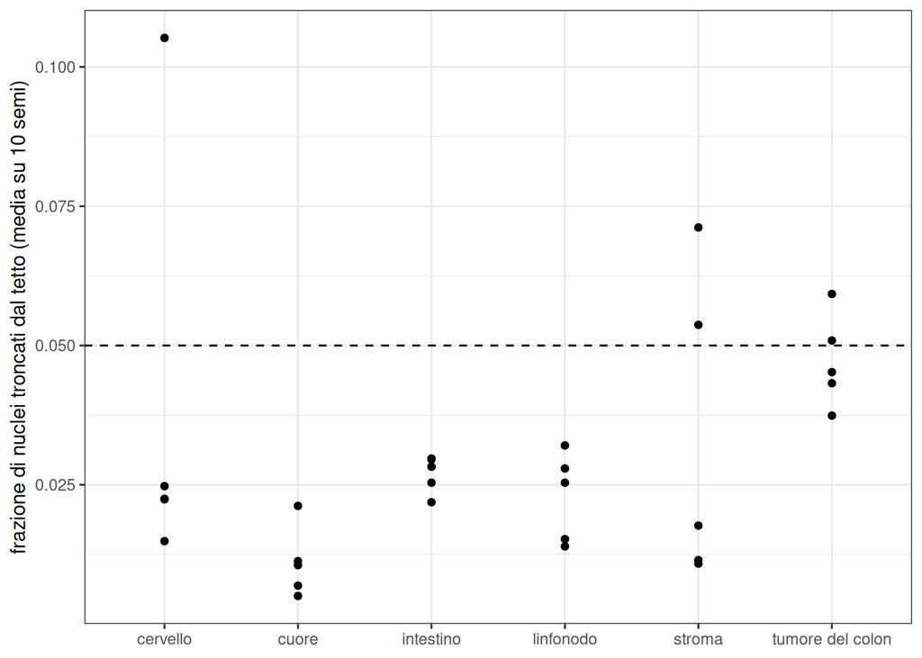

## Cellule quasi senza citoplasma per ROI (P-3)

| tessuto | ROI | simulato | reale |
| --- | --- | --- | --- |
| intestino | r1 | 0 | 0.00132 |
| intestino | r2 | 0 | 0.000678 |
| intestino | r3 | 0 | 0.00202 |
| intestino | r4 | 0 | 0.00156 |
| intestino | r5 | 0 | 0.00153 |
| tumore del colon | r1 | 0.0642 | 0.0175 |
| tumore del colon | r2 | 0.0533 | 0.0154 |
| tumore del colon | r3 | 0.0480 | 0.0159 |
| tumore del colon | r4 | 0.0708 | 0.0287 |
| tumore del colon | r5 | 0.0547 | 0.0245 |
| stroma | r1 | 0 | 0.00462 |
| stroma | r2 | 0 | 0.00312 |
| stroma | r3 | 0 | 0.00885 |
| stroma | r4 | 0 | 0.00834 |
| stroma | r5 | 0 | 0.0208 |
| linfonodo | f1 | 0 | 0.00322 |
| linfonodo | f2 | 0 | 0.00267 |
| linfonodo | p1 | 0 | 0.00168 |
| linfonodo | p2 | 0 | 0.00284 |
| linfonodo | p3 | 0 | 0.00116 |
| cervello | r1 | 0 | 0 |
| cervello | r2 | 0 | 0 |
| cervello | r3 | 0 | 0 |
| cervello | r4 | 0 | 0 |
| cervello | r5 | 0 | 0 |
| cuore | r1 | 0 | 0 |
| cuore | r2 | 0 | 0 |
| cuore | r3 | 0 | 0 |
| cuore | r4 | 0 | 0 |
| cuore | r5 | 0 | 0 |

## Equivalenza con il prototipo (G-4a)

| archetype | units | cells | dA_rel_max | sym_rel_max | cells_sym_gt1e6 | cells_beyond_grid_bound | units_same_ncap |
| --- | --- | --- | --- | --- | --- | --- | --- |
| A1 | 50 | 386870 | 7e-07 | 8e-07 | 0 | 0 | 50 |
| A2 | 50 | 327210 | 4e-07 | 8e-07 | 0 | 0 | 50 |
| A3 | 50 | 212980 | 3e-07 | 6e-07 | 0 | 0 | 50 |
| A4 | 50 | 1393910 | 4e-07 | 8e-07 | 0 | 0 | 50 |
| A5 | 50 | 41420 | 3e-07 | 5e-07 | 0 | 0 | 50 |
| A6 | 50 | 49260 | 4e-07 | 4e-07 | 0 | 0 | 50 |

## Da dove vengono i numeri del riassunto

| frase del riassunto | fonte (tabella o file, riga) | valore letto |
| --- | --- | --- |
| intestino 0.50, tumore del colon 0.48, stroma 0.18, linfonodo 0.74, cervello 0.08, cuore 0.05 | `results/S1.4d/S1.4d_predictions.csv`, righe P-1, colonna `est` | 0.5006, 0.4817, 0.1816, 0.7439, 0.0834, 0.0491 |
| tu 0.50, 0.37, 0.18, 0.55, 0.08, 0.02; margine del linfonodo fino a 0.75 | `results/R2c/R2c_posthoc_ci.csv`, righe «due stadi», colonne `est`, `hi` | 0.500, 0.367, 0.183, 0.550 (hi 0.750), 0.083, 0.017 |
| modello vecchio: zero in intestino, tumore e stroma, 2 su 100 nel linfonodo | `results/S1.4d/S1.4d_counterproof.csv`, righe CP-1 | 0, 0, 0, 0.0187 |
| con i centri StarDist 0.41 | `results/S1.4d/S1.4d_predictions.csv`, riga P-4 | 0.4122 |
| StarDist vede meno nuclei | BACKLOG BL-121 (n Space Ranger / n StarDist) | 1.15–1.40 |
| 6 % delle cellule del tumore quasi senza citoplasma, al più 3 % nei tessuti reali | `results/S1.4d/S1.4d_predictions.csv` riga P-3 A2; `S1.4d_p3_roi.csv`, massimo di `real_nc95` in A2 | 0.0582; 0.0287 |
| il modello di taglia chiede nuclei così grandi nel 6 %, contro il 2 % dei nuclei veri | `results/S1.4d/S1.4d_posthoc_nc.csv`, media per ROI poi per tessuto, `tgt_nc95`, `real_nc95` (A2) | 0.0582; 0.0204 |
| alcuni nuclei veri superano il territorio (nessun limite nel tumore) | BIO_REFERENCES B-122, q99 del rapporto nucleo/territorio | 1.051 |
| 6.8 milioni di nuclei, nessuno fuori, nessuna coppia sovrapposta | `results/S1.4d/S1.4d_g3_invariants.csv`, somma di `cells`, `c3_geos`, `c3_sf`, `overlap_pairs` | 6 823 226; 0; 0; 0 |
| 2.4 milioni di nuclei confrontati con il prototipo, aree a meno di un milionesimo, stessi nuclei al limite | `results/S1.4d/S1.4d_g4a_equivalence.csv` (`cells`, max `dA_rel_max`); `S1.4d_g4a_cells.csv` (`diff_trunc`) | 2 411 650; 7.45e-7; 0 |
| modello vecchio identico a prima | `results/S1.4d/S1.4d_g4b_legacy.csv` | 330/330 identici |
| 450 000 cellule in 3 minuti e 45 secondi, contro 10 minuti e 23 secondi del prototipo | `results/S1.4d/S1.4d_perf.csv` (media di `times_s`); `docs/BACKLOG.md` BL-122 | 224.6 s; 622.7 s (n = 449 536) |
| un nucleo di 0.18 µm² sbaglia di 1.5 milionesimi; nei tessuti reali al più 0.7 milionesimi | `results/S1.4d/S1.4d_gates.csv` riga G-3 area; `S1.4d_g3_invariants.csv` (`area_rel_max`); report, sezione G-3 | 1.46e-6 (nucleo 0.176 µm²); 7.43e-7 |
| più di venti volte più piccolo del nucleo vero più piccolo (4 µm²) | `/mnt/micron/geo_spatialtrans/S1.4/real/*.rds`, minimo di `a_n` nell’insieme di valutazione (calcolato in chat il 2026-10-20, script `/tmp/minreal.R`) | 4.045 µm² (rapporto 23) |
| sette volte sotto quello che la griglia permette | report, sezione G-3: limite 1.06e-5 contro errore 1.46e-6 | 7.2 |
| con limite al 95 % i troncati salirebbero da 4.7 % a 5.5 %; al 90 % a 6.5 % | `S1.4d_predictions.csv` P-2 A2; `S1.4d_posthoc_nc.csv` `b4_phi095`, `b4_phi090` (A2) | 0.0472; 0.0552; 0.0647 |
| 8 nuclei in più parti su 2.4 milioni, uno con due quinti dell’area in frammenti staccati | `S1.4d_g3_invariants.csv` `multipart` (primary_tissue); revisione «codice», rilievo F-07 | 8; 41 % |